# Today

You can get today's lecture by from mikheyevlab.github.io/B02-Fall-2015

- introduction to Python part II
  - dictionaries
  - control structures
  - working with files
  - debugging code
- introduction to DNA
- Biopython to the rescue

Questions from last lecture:

- How do you reverse a list using slice notation?
- In

  `print "Once the number %.2f, being the number of the counting, be reached, then lobbest thou the Holy Hand Grenade." % float("3")`

why is it necessary to use *float*?

# Dictionaries

- This is perhaps the most sophisticated useful of the built-in data types
- dictionaries allow you to study relationships between data
- dictionaries have 'keys' and 'values':
  - they report a value, given a key

```python
mydict = {}
mydict['a'] = 1
mydict['g'] = 2
mydict[3] = 'goat'    # you can use numbers for keys
myvar = 4
mydict[myvar] = 'spam'   # or even variables (and other data structures)

print mydict
print mydict[3]
```

```
{'a': 1, 3: 'goat', 4: 'spam', 'g': 2}
goat
```

## Dictionary methods

Deleteion

```python
print mydict
del mydict['a']
print mydict
```

```
{'a': 1, 3: 'goat', 4: 'spam', 'g': 2}
{3: 'goat', 4: 'spam', 'g': 2}
```

Accessing keys

```python
print mydict.keys()
```

```
[3, 4, 'g']
```

**Important:** The dictionary keys are not in any particular order. If you want them sorted, you have to do so explicitly.

```python
mydict = {'a':1,'c':3,'b':42}
print sorted(mydict.keys())
```

```
['a', 'b', 'c']
```

You can also get a list of values (again, **not** sorted)

```python
print mydict.values()
```

```
[1, 3, 42]
```

# Control strctures (if... then...)

Often, our programs need to make decisions We do this by evaluating whether they are true or not

```python
pounds = 1
if pounds >= 1:
    print "Definitely African swallow"
else:
    print "European swallow?"
```

```
Definitely African swallow
```

## All variables in python have a truth value

- most everything is 'true' in the eyes of python, except
  - False
  - 0
  - empty structues (strings, lists, dictionaries, etc.)

```python
a = 'Holy Grail'
if a:
    print "We have a quest"
#see how an empty string evaluates to false
b = ''
if b:
    print "We don't have a quest"
```

```
We have a quest
```

You can combina and negate logical expressions using boolean arithmetic

```python
if a or b:
    print "We have a quest"

    # negate the expression
if not (a or b):
    print "We don't have a quest"
```

```
We have a quest
```

- If you are into this kind of thing, you can minimize brackets by learning the rules of precedence.
- However, it is good programming practice to have parentheses, which make code easier to read.

# Loops

- Very oftern computers have to do the same thing over and over
- The most common type of loop is a 'for loop'

```python
for i in range(5):
    print i
```

```
0
1
2
3
4
```

The 'while loop' can be used to accomplish an equivalent task

```python
#'while loop'
count = 0
while count < 5:
    print count
    count +=1
```

```
0
1
2
3
4
```

## Questions

- Why would you use one loop over the other?
- Can you think of a danger in using while loops?

# Integrating control structures with loops

To make loops interesting, you have to make them smarter with control structures

```python
stop_count = 3
for i in range(5):
    if i == 1:
        print "skipping 1"
        continue
    if i >= stop_count:
        print "interrupted!"
        break
    print "counting %i" %i
```

```
counting 0
skipping 1
counting 2
interrupted!
```

In python, there is a cool way to know whether a for loop has finished, or was interrupted

```python
stop_count = 6
for i in range(5):
    if i >= stop_count:
        print "interrupted!"
        break
    print "counting %i" %i
else:
    print "finished counting"
```

```
counting 0
counting 1
counting 2
counting 3
counting 4
finished counting
```

# Working with files

- A lot of tasks in bioinformatics have to do with reading and writing text files
- in python an open file is addressed by a 'handle'
- let's create a file

```python
outfile = open("test.txt","w") # open file for writing
for i in range(5):
    outfile.write(str(i)+"\n")  # note that we are converting the integer into a string and adding a "newline" character
outfile.close()  # closing files handles is a good idea, although python closes everything automatically when the script finishes
                 #in ipython it is probably not a great idea to clog it with open file handles, so keep track of what you open

#using python to execute a shell command
!ls
```

```
01. Introduction.ipynb                                                           b02 syllabus.pdf
01. Introduction.slides.html                                                     media
02. Data structures, control structures, debugging and central domga.ipynb       schedule.xlsx
02. Data structures, control structures, debugging and central domga.slides.html syllabus.docx
README.md                                                                        test.txt
```

Now, let's see what's inside using bash commands

```python
cat test.txt
```

```
0
1
2
3
4
```

Now that we have a file, let's read it

```python
infile = open("test.txt")
for line in infile:
    print line
infile.close()
```

```
0

1

2

3

4
```

Why is the output double-spaced?

Here's are two ways to fix it

```python
print "telling python not to print newline"
infile = open("test.txt")
for line in infile:
    print line,
infile.close()

print "stripping newline from string"
infile = open("test.txt")
for line in infile:
    print line.rstrip()
infile.close()
```

```
telling python not to print newline
0
1
2
3
4
stripping newline from string
0
1
2
3
4
```

In an actual script, because python will close my file handles, I would write this loop as below.

However, this is arguably bad programming practice, and you shouldn't do it, at least not in an ipython notebook.

```python
for line in open("test.txt"):
    print line.rstrip()
```

```
0
1
2
3
4
```

## Debugging python code

### How to find logical errors

```python
macbeth = """Tomorrow, and tomorrow, and tomorrow,
             Creeps in this petty pace from day to day,
             To the last syllable of recorded time"""
counts = {}
for word in macbeth.split():
    word = word.upper().rstrip().rstrip(",")
    counts[word] = macbeth.upper().count(word)

for word in counts:
    print word, counts[word]
```

```
AND 2
PETTY 1
CREEPS 1
TO 5
THIS 1
OF 1
TIME 1
RECORDED 1
DAY 2
SYLLABLE 1
PACE 1
IN 1
FROM 1
THE 1
TOMORROW 3
LAST 1
```

Is this correct?

How can we check?

One option is to write a quick function that cross checks out output vs what we expect

```python
counts = {}
for word in macbeth.split():
    word = word.upper().rstrip()
    counts[word] = macbeth.upper().count(word)

total_words = 0
for word in counts:
    total_words += counts[word]
print "%i words in dictionary, %i words in text" % (total_words, len(macbeth.split()))
```

```
25 words in dictionary, 21 words in text
```

Now we really know something is not right.

Let's go into the code and explore it:

```python
import pdb
counts = {}
for word in macbeth.split():
    word = word.upper().rstrip()
    if word == "TO":
        pdb.set_trace()
        # type in:
            # macbeth.upper().find(word)
            ## find after first match
            # macbeth.upper().find(word,1)
            # macbeth[0:10]
            # macbeth[14:24]
```

```
> <ipython-input-21-b3916f723b08>(3)<module>()
-> for word in macbeth.split():
(Pdb) macbeth.upper().find(word)
0
(Pdb) macbeth.upper().find(word,1)
14
(Pdb) macbeth[0:10]
'Tomorrow, '
(Pdb) macbeth[14:24]
'tomorrow, '
(Pdb) quit
```

[output not shown]

To debug code you can set breakpoints and explore the environment.

It helps to write in loops that stop at particular points when something seems to go wrong.

# And finally a bit of biology

I am going to introduce just a bit of biology, but the most important bit

Here is the chemical structure of DNA as inferred by Watson and Crick (with an unacknowledged assist from Rosalind Franklin):

[figure not shown]

```python
from IPython.display import display_pretty, display_html, Image
Image(filename='media/doublehelix.png')
```

DNA is held togethe by electrostatic forces between the bases

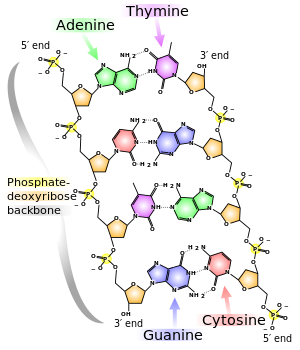

```python
Image('media/DNA_chemical_structure.png')
```

Note that there are three bonds between **G**uanine and **C**ytosine, and two between **A**denine and **T**hymine

What effect do you think this has?

In the cell DNA stores the genetic information. It is typically double-stranded, which adds redundancy.

This information is then *transcribed* into RNA, which is a related molecule, although it has one different base

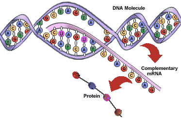

```python
Image('media/transcription.png')
```

The RNA-specific base is called **Uracil**.

What base does it pair with?

Finally, RNA is **translated** into protein.

Proteins are the things what do the work.

What we see in the mirror is all protein.

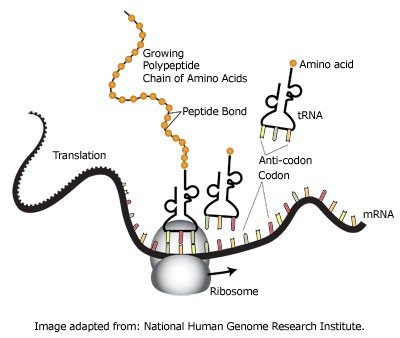

```python
Image('media/translation.jpg')
```

Note that every three bases on an RNA strand make up one **amino acid**, which is a fundamental unit of protein structure

A three-letter sequence of bases that codes for an amino acid is called a **codon**

# This whole process (DNA -> RNA -> protein) is called the "central dogma of molecular biology"

It is improtant to know

# Working with biological strings

- the structure of DNA is analogous to a string
- it is ordered, and has an alphabet
- this is indeed how we model them in python, using the biopython set of libraries

```python
from Bio.Seq import Seq
from Bio.Alphabet import generic_dna, generic_protein
myseq = Seq("agcccggcgatgtaa",generic_dna)
print myseq
```

```
agcccggcgatgtaa
```

You can get both strands of the double helix:

```python
print myseq
print "".join(["|"]*len(myseq))
print myseq.complement()
```

```
agcccggcgatgtaa
|||||||||||||||
tcgggccgctacatt
```

Observe that I treated myseq has properties of a string, and we can get its length with the *len* command

You can get more information on what you can do with strings (and other objects using *dir*)

```python
dir(myseq)
```

```
['__add__',
 '__class__',
 '__cmp__',
 '__contains__',
 '__delattr__',
 '__dict__',
 '__doc__',
 '__format__',
 '__getattribute__',
 '__getitem__',
 '__hash__',
 '__init__',
 '__len__',
 '__module__',
 '__new__',
 '__radd__',
 '__reduce__',
 '__reduce_ex__',
 '__repr__',
 '__setattr__',
 '__sizeof__',
 '__str__',
 '__subclasshook__',
 '__weakref__',
 '_data',
 '_get_seq_str_and_check_alphabet',
 'alphabet',
 'back_transcribe',
 'complement',
 'count',
 'endswith',
 'find',
 'lower',
 'lstrip',
 'reverse_complement',
 'rfind',
 'rsplit',
 'rstrip',
 'split',
 'startswith',
 'strip',
 'tomutable',
 'tostring',
 'transcribe',
 'translate',
 'ungap',
 'upper']
```

And of course using an ipython magic

```python
?myseq
```

## Implementing the central dogma of molecular biology in python

Transcribing DNA to RNA

```python
print myseq.transcribe()
```

```
agcccggcgauguaa
```

RNA to protein

```python
print myseq.transcribe().translate()
```

```
SPAM*
```

In most cases, you can shortcut the RNA step, if you are interested in the protein directly

```python
print myseq.translate()
```

```
SPAM*
```

By the way, what does the asterisk ("*") mean?

# Homework for Thursday

- [rosalind.info](http://rosalind.info/) problem set